# Reproducible Reserach Assignment 1

```r
setwd("./")
data <- read.csv("activity.csv")
names(data)
```

```
## [1] "steps"    "date"     "interval"
```

Part1: What is mean total number of steps taken per day?

In this step, first the data will be subset to small chunks per each day, then mean and median of each subset will be calculated. At the end, meanPerDay and medianPerDay variables show mean and median value for each day.

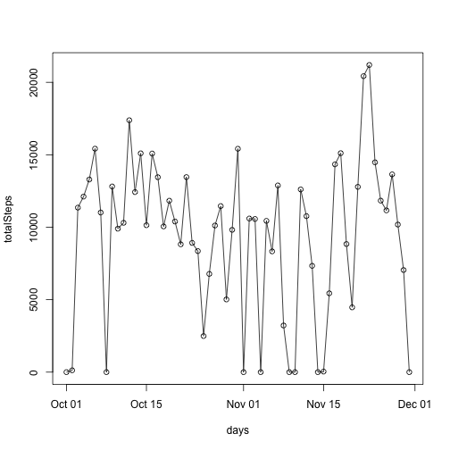

```r
days <- seq(from = as.Date("2012-10-01"), to = as.Date("2012-11-30"), by = "days")

stepsMean <- vector("numeric", length = length(days))
stepsMedian <- vector("numeric", length = length(days))
totalSteps <- vector("numeric", length = length(days))
for (i in seq_along(days)) {
    b <- subset(data, as.Date(data$date, format = "%Y-%m-%d") == days[i])
    stepsMean[i] <- mean(as.numeric(b$steps), na.rm = TRUE)
    stepsMedian[i] <- median(as.numeric(b$steps), na.rm = TRUE)
    totalSteps[i] <- sum(as.numeric(b$steps), na.rm = TRUE)
}

plot(days, totalSteps)
lines(days, totalSteps)
```

```r
meanPerDay <- cbind(as.character(days), as.character(stepsMean))
medianPerDay <- cbind(as.character(days), as.character(stepsMedian))
print(meanPerDay)
```

```
##       [,1]         [,2]
##  [1,] "2012-10-01" "NaN"
##  [2,] "2012-10-02" "0.4375"
##  [3,] "2012-10-03" "39.4166666666667"
##  [4,] "2012-10-04" "42.0694444444444"
##  [5,] "2012-10-05" "46.1597222222222"
##  [6,] "2012-10-06" "53.5416666666667"
##  [7,] "2012-10-07" "38.2465277777778"
##  [8,] "2012-10-08" "NaN"
##  [9,] "2012-10-09" "44.4826388888889"
## [10,] "2012-10-10" "34.375"
## [11,] "2012-10-11" "35.7777777777778"
## [12,] "2012-10-12" "60.3541666666667"
## [13,] "2012-10-13" "43.1458333333333"
## [14,] "2012-10-14" "52.4236111111111"
```

[output cut: 47 more lines]

```r
print(medianPerDay)
```

```
##       [,1]         [,2]
##  [1,] "2012-10-01" NA
##  [2,] "2012-10-02" "0"
##  [3,] "2012-10-03" "0"
##  [4,] "2012-10-04" "0"
##  [5,] "2012-10-05" "0"
##  [6,] "2012-10-06" "0"
##  [7,] "2012-10-07" "0"
##  [8,] "2012-10-08" NA
##  [9,] "2012-10-09" "0"
## [10,] "2012-10-10" "0"
## [11,] "2012-10-11" "0"
## [12,] "2012-10-12" "0"
## [13,] "2012-10-13" "0"
## [14,] "2012-10-14" "0"
```

[output cut: 47 more lines]

Part2: What is the average daily activity pattern?

In this step, first the data will be subset to small chunks per each 5 minutes interval of all days collectively, then mean of each subset will be calculated. and plot of mean of nterval versus time interval will be made.

```r
# time<-seq(from=0,to=2400,by=5)
start.date <- "2012-10-01"
start.time <- "00:00:00"
interval <- 5
increment.mins <- interval * 60
x <- paste(start.date, start.time)
time <- vector()

for (i in 1:288) {
    temp <- strftime(strptime(x, format = "%Y-%m-%d %H:%M:%S") + i * increment.mins,
        "%H%M")
    time[i] <- temp
}


intervalMean <- vector("numeric", length = length(time))
for (i in seq_along(time)) {
    c <- subset(data, as.numeric(data$interval) == as.numeric(time[i]))
    intervalMean[i] <- mean(c$steps, na.rm = TRUE)
}
print(intervalMean)
```

```
##   [1]   0.33962   0.13208   0.15094   0.07547   2.09434   0.52830   0.86792
##   [8]   0.00000   1.47170   0.30189   0.13208   0.32075   0.67925   0.15094
##  [15]   0.33962   0.00000   1.11321   1.83019   0.16981   0.16981   0.37736
##  [22]   0.26415   0.00000   0.00000   0.00000   1.13208   0.00000   0.00000
##  [29]   0.13208   0.00000   0.22642   0.00000   0.00000   1.54717   0.94340
##  [36]   0.00000   0.00000   0.00000   0.00000   0.20755   0.62264   1.62264
##  [43]   0.58491   0.49057   0.07547   0.00000   0.00000   1.18868   0.94340
##  [50]   2.56604   0.00000   0.33962   0.35849   4.11321   0.66038   3.49057
##  [57]   0.83019   3.11321   1.11321   0.00000   1.56604   3.00000   2.24528
##  [64]   3.32075   2.96226   2.09434   6.05660  16.01887  18.33962  39.45283
##  [71]  44.49057  31.49057  49.26415  53.77358  63.45283  49.96226  47.07547
##  [78]  52.15094  39.33962  44.01887  44.16981  37.35849  49.03774  43.81132
##  [85]  44.37736  50.50943  54.50943  49.92453  50.98113  55.67925  44.32075
##  [92]  52.26415  69.54717  57.84906  56.15094  73.37736  68.20755 129.43396
##  [99] 157.52830 171.15094 155.39623 177.30189 206.16981 195.92453 179.56604
```

[output cut: 27 more lines]

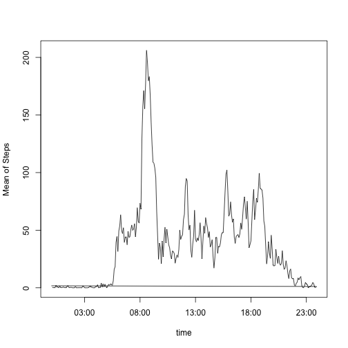

```r
plot(strptime(time, format = "%H%M"), intervalMean, type = "l", xlab = "time",
    ylab = "Mean of Steps")
```

According to this plot, 08:35 interval has the maximum average of steps over all days.

Part3: Imputing missing values

number of rows with a missing value (i.e. NAs) is 2304

In this part, first rows of data with a missing value are detected, then they are replaced by mean of that interval over all other days and produce a new data set.

Then the new data will be subsetized for each day separately and mean and median of data over each day will be calculated.

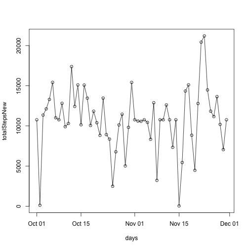

```r
index <- which(is.na(data$steps))
new_data <- data
for (i in index) {
    new_data$steps[i] <- intervalMean[which(as.numeric(time) == new_data$interval[i])]
}

stepsMeanNew <- vector("numeric", length = length(days))
stepsMedianNew <- vector("numeric", length = length(days))
totalStepsNew <- vector("numeric", length = length(days))

for (i in seq_along(days)) {
    b <- subset(new_data, as.Date(new_data$date, format = "%Y-%m-%d") == days[i])
    stepsMeanNew[i] <- mean(as.numeric(b$steps), na.rm = TRUE)
    stepsMedianNew[i] <- median(as.numeric(b$steps), na.rm = TRUE)
    totalStepsNew[i] <- sum(as.numeric(b$steps), na.rm = TRUE)
}

plot(days, totalStepsNew)
lines(days, totalStepsNew)
```

```r
meanPerDayNew <- cbind(as.character(days), as.character(stepsMeanNew))
medianPerDayNew <- cbind(as.character(days), as.character(stepsMedianNew))
print(meanPerDayNew)
```

```
##       [,1]         [,2]
##  [1,] "2012-10-01" "37.3825995807128"
##  [2,] "2012-10-02" "0.4375"
##  [3,] "2012-10-03" "39.4166666666667"
##  [4,] "2012-10-04" "42.0694444444444"
##  [5,] "2012-10-05" "46.1597222222222"
##  [6,] "2012-10-06" "53.5416666666667"
##  [7,] "2012-10-07" "38.2465277777778"
##  [8,] "2012-10-08" "37.3825995807128"
##  [9,] "2012-10-09" "44.4826388888889"
## [10,] "2012-10-10" "34.375"
## [11,] "2012-10-11" "35.7777777777778"
## [12,] "2012-10-12" "60.3541666666667"
## [13,] "2012-10-13" "43.1458333333333"
## [14,] "2012-10-14" "52.4236111111111"
```

[output cut: 47 more lines]

```r
print(medianPerDayNew)
```

```
##       [,1]         [,2]
##  [1,] "2012-10-01" "34.1132075471698"
##  [2,] "2012-10-02" "0"
##  [3,] "2012-10-03" "0"
##  [4,] "2012-10-04" "0"
##  [5,] "2012-10-05" "0"
##  [6,] "2012-10-06" "0"
##  [7,] "2012-10-07" "0"
##  [8,] "2012-10-08" "34.1132075471698"
##  [9,] "2012-10-09" "0"
## [10,] "2012-10-10" "0"
## [11,] "2012-10-11" "0"
## [12,] "2012-10-12" "0"
## [13,] "2012-10-13" "0"
## [14,] "2012-10-14" "0"
```

[output cut: 47 more lines]

In this step, days of data will be labled as weekdays or weekends, then data will be subsetized to two groups of weekdays and weekends. The each of these groups will be subsetized separately to groups with the same five minute time interval, average of steps over each interval will be calculated and then will be plotted.

```r
new_data$weekDays <- weekdays(strptime(new_data$date, format = "%Y-%m-%d"))
weekday_level <- c("Monday", "Tuesday", "Wednesday", "Thursday", "Friday")
weekends_level <- c("Saturday", "Sunday")
new_data$weekdays_lable <- factor(new_data$weekDays, levels = c(weekday_level,
    weekends_level), labels = c("Weekday", "Weekday", "Weekday", "Weekday",
    "Weekday", "Weekend", "Weekend"))
```

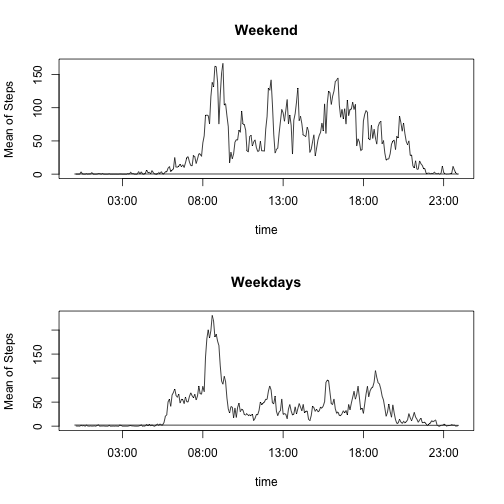

```r
new_data_weekdays <- subset(new_data, new_data$weekdays_lable == "Weekday")
new_data_weekend <- subset(new_data, new_data$weekdays_lable == "Weekend")

intervalMeanWeekdays <- vector("numeric", length = length(time))
for (i in seq_along(time)) {
    c <- subset(new_data_weekdays, as.numeric(new_data_weekdays$interval) ==
        as.numeric(time[i]))
    intervalMeanWeekdays[i] <- mean(c$steps, na.rm = TRUE)
}


intervalMeanWeekends <- vector("numeric", length = length(time))
for (i in seq_along(time)) {
    c <- subset(new_data_weekend, as.numeric(new_data_weekend$interval) == as.numeric(time[i]))
    intervalMeanWeekends[i] <- mean(c$steps, na.rm = TRUE)
}

par(mfrow = c(2, 1))
plot(strptime(time, format = "%H%M"), intervalMeanWeekends, type = "l", xlab = "time",
    ylab = "Mean of Steps", main = "Weekend")
plot(strptime(time, format = "%H%M"), intervalMeanWeekdays, type = "l", xlab = "time",
    ylab = "Mean of Steps", main = "Weekdays")
```